# Risk Factor Analysis

## Outcome Variable

**Outcome Variable:** y_rate_len

## Predictor Variables

**Intervention Variable:** nhh

**Adjustment Set:**

- arm
- W_mage
- meducyrs
- feducyrs
- W_mhtcm
- W_mwtkg
- W_mbmi
- W_nrooms
- trth2o
- cleanck
- impfloor
- impsan
- safeh20
- delta_W_mage
- delta_meducyrs
- delta_feducyrs
- delta_W_mhtcm
- delta_W_mwtkg
- delta_W_mbmi
- delta_W_nrooms
- delta_trth2o
- delta_cleanck
- delta_impfloor
- delta_impsan
- delta_safeh20

## Stratifying Variables

The analysis was stratified on these variable(s):

- agecat
- studyid
- country

## Data Summary

| agecat | studyid | country | nhh | n_cell | n |
| --- | --- | --- | --- | --- | --- |
| 0-3 months | ki1017093-NIH-Birth | BANGLADESH | 3 or less | 101 | 566 |
| 0-3 months | ki1017093-NIH-Birth | BANGLADESH | 4-5 | 239 | 566 |
| 0-3 months | ki1017093-NIH-Birth | BANGLADESH | 6-7 | 132 | 566 |
| 0-3 months | ki1017093-NIH-Birth | BANGLADESH | 8+ | 94 | 566 |
| 0-3 months | ki1017093b-PROVIDE | BANGLADESH | 3 or less | 123 | 634 |
| 0-3 months | ki1017093b-PROVIDE | BANGLADESH | 4-5 | 291 | 634 |
| 0-3 months | ki1017093b-PROVIDE | BANGLADESH | 6-7 | 135 | 634 |
| 0-3 months | ki1017093b-PROVIDE | BANGLADESH | 8+ | 85 | 634 |
| 0-3 months | ki1017093c-NIH-Crypto | BANGLADESH | 3 or less | 107 | 720 |
| 0-3 months | ki1017093c-NIH-Crypto | BANGLADESH | 4-5 | 324 | 720 |
| 0-3 months | ki1017093c-NIH-Crypto | BANGLADESH | 6-7 | 169 | 720 |
| 0-3 months | ki1017093c-NIH-Crypto | BANGLADESH | 8+ | 120 | 720 |
| 0-3 months | ki1000108-IRC | INDIA | 3 or less | 53 | 377 |
| 0-3 months | ki1000108-IRC | INDIA | 4-5 | 146 | 377 |
| 0-3 months | ki1000108-IRC | INDIA | 6-7 | 99 | 377 |
| 0-3 months | ki1000108-IRC | INDIA | 8+ | 79 | 377 |
| 3-6 months | ki1017093-NIH-Birth | BANGLADESH | 3 or less | 89 | 523 |
| 3-6 months | ki1017093-NIH-Birth | BANGLADESH | 4-5 | 223 | 523 |
| 3-6 months | ki1017093-NIH-Birth | BANGLADESH | 6-7 | 126 | 523 |
| 3-6 months | ki1017093-NIH-Birth | BANGLADESH | 8+ | 85 | 523 |
| 3-6 months | ki1017093b-PROVIDE | BANGLADESH | 3 or less | 102 | 574 |
| 3-6 months | ki1017093b-PROVIDE | BANGLADESH | 4-5 | 270 | 574 |
| 3-6 months | ki1017093b-PROVIDE | BANGLADESH | 6-7 | 124 | 574 |
| 3-6 months | ki1017093b-PROVIDE | BANGLADESH | 8+ | 78 | 574 |
| 3-6 months | ki1017093c-NIH-Crypto | BANGLADESH | 3 or less | 101 | 695 |
| 3-6 months | ki1017093c-NIH-Crypto | BANGLADESH | 4-5 | 316 | 695 |
| 3-6 months | ki1017093c-NIH-Crypto | BANGLADESH | 6-7 | 163 | 695 |
| 3-6 months | ki1017093c-NIH-Crypto | BANGLADESH | 8+ | 115 | 695 |
| 3-6 months | ki1000108-IRC | INDIA | 3 or less | 57 | 397 |
| 3-6 months | ki1000108-IRC | INDIA | 4-5 | 154 | 397 |
| 3-6 months | ki1000108-IRC | INDIA | 6-7 | 103 | 397 |
| 3-6 months | ki1000108-IRC | INDIA | 8+ | 83 | 397 |
| 6-12 months | ki1017093-NIH-Birth | BANGLADESH | 3 or less | 87 | 482 |
| 6-12 months | ki1017093-NIH-Birth | BANGLADESH | 4-5 | 202 | 482 |
| 6-12 months | ki1017093-NIH-Birth | BANGLADESH | 6-7 | 112 | 482 |
| 6-12 months | ki1017093-NIH-Birth | BANGLADESH | 8+ | 81 | 482 |
| 6-12 months | ki1017093b-PROVIDE | BANGLADESH | 3 or less | 97 | 545 |
| 6-12 months | ki1017093b-PROVIDE | BANGLADESH | 4-5 | 258 | 545 |
| 6-12 months | ki1017093b-PROVIDE | BANGLADESH | 6-7 | 114 | 545 |
| 6-12 months | ki1017093b-PROVIDE | BANGLADESH | 8+ | 76 | 545 |
| 6-12 months | ki1017093c-NIH-Crypto | BANGLADESH | 3 or less | 95 | 676 |
| 6-12 months | ki1017093c-NIH-Crypto | BANGLADESH | 4-5 | 307 | 676 |
| 6-12 months | ki1017093c-NIH-Crypto | BANGLADESH | 6-7 | 164 | 676 |
| 6-12 months | ki1017093c-NIH-Crypto | BANGLADESH | 8+ | 110 | 676 |
| 6-12 months | ki1000108-IRC | INDIA | 3 or less | 57 | 400 |
| 6-12 months | ki1000108-IRC | INDIA | 4-5 | 154 | 400 |
| 6-12 months | ki1000108-IRC | INDIA | 6-7 | 104 | 400 |
| 6-12 months | ki1000108-IRC | INDIA | 8+ | 85 | 400 |
| 6-12 months | ki1000304b-SAS-FoodSuppl | INDIA | 3 or less | 26 | 332 |
| 6-12 months | ki1000304b-SAS-FoodSuppl | INDIA | 4-5 | 146 | 332 |
| 6-12 months | ki1000304b-SAS-FoodSuppl | INDIA | 6-7 | 106 | 332 |
| 6-12 months | ki1000304b-SAS-FoodSuppl | INDIA | 8+ | 54 | 332 |
| 6-12 months | ki1148112-LCNI-5 | MALAWI | 3 or less | 119 | 430 |
| 6-12 months | ki1148112-LCNI-5 | MALAWI | 4-5 | 183 | 430 |
| 6-12 months | ki1148112-LCNI-5 | MALAWI | 6-7 | 95 | 430 |
| 6-12 months | ki1148112-LCNI-5 | MALAWI | 8+ | 33 | 430 |
| 12-24 months | ki1017093-NIH-Birth | BANGLADESH | 3 or less | 74 | 421 |
| 12-24 months | ki1017093-NIH-Birth | BANGLADESH | 4-5 | 181 | 421 |
| 12-24 months | ki1017093-NIH-Birth | BANGLADESH | 6-7 | 97 | 421 |
| 12-24 months | ki1017093-NIH-Birth | BANGLADESH | 8+ | 69 | 421 |
| 12-24 months | ki1017093b-PROVIDE | BANGLADESH | 3 or less | 86 | 458 |
| 12-24 months | ki1017093b-PROVIDE | BANGLADESH | 4-5 | 213 | 458 |
| 12-24 months | ki1017093b-PROVIDE | BANGLADESH | 6-7 | 96 | 458 |
| 12-24 months | ki1017093b-PROVIDE | BANGLADESH | 8+ | 63 | 458 |
| 12-24 months | ki1017093c-NIH-Crypto | BANGLADESH | 3 or less | 68 | 495 |
| 12-24 months | ki1017093c-NIH-Crypto | BANGLADESH | 4-5 | 224 | 495 |
| 12-24 months | ki1017093c-NIH-Crypto | BANGLADESH | 6-7 | 125 | 495 |
| 12-24 months | ki1017093c-NIH-Crypto | BANGLADESH | 8+ | 78 | 495 |
| 12-24 months | ki1000108-IRC | INDIA | 3 or less | 57 | 396 |
| 12-24 months | ki1000108-IRC | INDIA | 4-5 | 151 | 396 |
| 12-24 months | ki1000108-IRC | INDIA | 6-7 | 103 | 396 |
| 12-24 months | ki1000108-IRC | INDIA | 8+ | 85 | 396 |
| 12-24 months | ki1148112-LCNI-5 | MALAWI | 3 or less | 89 | 307 |
| 12-24 months | ki1148112-LCNI-5 | MALAWI | 4-5 | 130 | 307 |
| 12-24 months | ki1148112-LCNI-5 | MALAWI | 6-7 | 64 | 307 |
| 12-24 months | ki1148112-LCNI-5 | MALAWI | 8+ | 24 | 307 |

The following strata were considered:

- agecat: 0-3 months, studyid: ki1000108-IRC, country: INDIA
- agecat: 0-3 months, studyid: ki1017093-NIH-Birth, country: BANGLADESH
- agecat: 0-3 months, studyid: ki1017093b-PROVIDE, country: BANGLADESH
- agecat: 0-3 months, studyid: ki1017093c-NIH-Crypto, country: BANGLADESH
- agecat: 12-24 months, studyid: ki1000108-IRC, country: INDIA
- agecat: 12-24 months, studyid: ki1017093-NIH-Birth, country: BANGLADESH
- agecat: 12-24 months, studyid: ki1017093b-PROVIDE, country: BANGLADESH
- agecat: 12-24 months, studyid: ki1017093c-NIH-Crypto, country: BANGLADESH
- agecat: 12-24 months, studyid: ki1148112-LCNI-5, country: MALAWI
- agecat: 3-6 months, studyid: ki1000108-IRC, country: INDIA
- agecat: 3-6 months, studyid: ki1017093-NIH-Birth, country: BANGLADESH
- agecat: 3-6 months, studyid: ki1017093b-PROVIDE, country: BANGLADESH
- agecat: 3-6 months, studyid: ki1017093c-NIH-Crypto, country: BANGLADESH
- agecat: 6-12 months, studyid: ki1000108-IRC, country: INDIA
- agecat: 6-12 months, studyid: ki1000304b-SAS-FoodSuppl, country: INDIA
- agecat: 6-12 months, studyid: ki1017093-NIH-Birth, country: BANGLADESH
- agecat: 6-12 months, studyid: ki1017093b-PROVIDE, country: BANGLADESH
- agecat: 6-12 months, studyid: ki1017093c-NIH-Crypto, country: BANGLADESH
- agecat: 6-12 months, studyid: ki1148112-LCNI-5, country: MALAWI

## Methods Detail

We’re interested in the causal parameters $E[Y_a]$ for all values of $a \in \mathcal{A}$. These parameters represent the mean outcome if, possibly contrary to fact, we intervened to set all units to have $A=a$. Under the randomization and positivity assumptions, these are identified by the statistical parameters $\psi_a=E_W[E_{Y|A,W}(Y|A=a,W)]$. In addition, we’re interested in the mean of $Y$, $E[Y]$ under no intervention (the observed mean). We will estimate these parameters by using SuperLearner to fit the relevant likelihood factors – $E_{Y|A,W}(Y|A=a,W)$ and $p(A=a|W)$, and then updating our likelihood fit using a joint TMLE.

For unadjusted analyses ($W=\{\}$), initial likelihoods were estimated using Lrnr_glm to estimate the simple $E(Y|A)$ and Lrnr_mean to estimate $p(A)$. For adjusted analyses, a small library containing Lrnr_glmnet, Lrnr_xgboost, and Lrnr_mean was used.

# Results Detail

## Results Plots

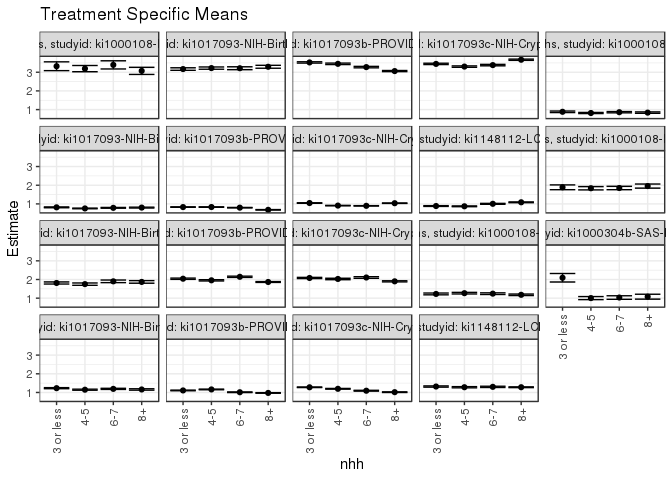

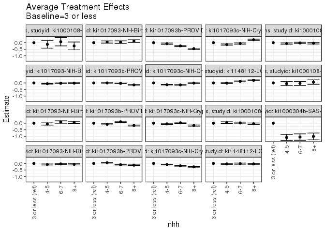

## Results Table

### Parameter: TSM

| agecat | studyid | country | intervention_level | baseline_level | estimate | ci_lower | ci_upper |
| --- | --- | --- | --- | --- | --- | --- | --- |
| 0-3 months | ki1000108-IRC | INDIA | 3 or less | NA | 3.3230651 | 3.0871416 | 3.5589887 |
| 0-3 months | ki1000108-IRC | INDIA | 4-5 | NA | 3.1950831 | 3.0276486 | 3.3625177 |
| 0-3 months | ki1000108-IRC | INDIA | 6-7 | NA | 3.3950310 | 3.1768886 | 3.6131734 |
| 0-3 months | ki1000108-IRC | INDIA | 8+ | NA | 3.0729847 | 2.8828506 | 3.2631188 |
| 0-3 months | ki1017093-NIH-Birth | BANGLADESH | 3 or less | NA | 3.1708492 | 3.1034993 | 3.2381992 |
| 0-3 months | ki1017093-NIH-Birth | BANGLADESH | 4-5 | NA | 3.2227240 | 3.1614410 | 3.2840071 |
| 0-3 months | ki1017093-NIH-Birth | BANGLADESH | 6-7 | NA | 3.2152640 | 3.1385557 | 3.2919723 |
| 0-3 months | ki1017093-NIH-Birth | BANGLADESH | 8+ | NA | 3.2930327 | 3.2146679 | 3.3713974 |
| 0-3 months | ki1017093b-PROVIDE | BANGLADESH | 3 or less | NA | 3.5258881 | 3.4899615 | 3.5618147 |
| 0-3 months | ki1017093b-PROVIDE | BANGLADESH | 4-5 | NA | 3.4507188 | 3.4117423 | 3.4896953 |
| 0-3 months | ki1017093b-PROVIDE | BANGLADESH | 6-7 | NA | 3.2754011 | 3.2360346 | 3.3147675 |
| 0-3 months | ki1017093b-PROVIDE | BANGLADESH | 8+ | NA | 3.0626826 | 3.0320357 | 3.0933295 |
| 0-3 months | ki1017093c-NIH-Crypto | BANGLADESH | 3 or less | NA | 3.4466732 | 3.4112718 | 3.4820746 |
| 0-3 months | ki1017093c-NIH-Crypto | BANGLADESH | 4-5 | NA | 3.3038080 | 3.2668616 | 3.3407544 |
| 0-3 months | ki1017093c-NIH-Crypto | BANGLADESH | 6-7 | NA | 3.3826693 | 3.3452491 | 3.4200894 |
| 0-3 months | ki1017093c-NIH-Crypto | BANGLADESH | 8+ | NA | 3.6700670 | 3.6375441 | 3.7025899 |
| 3-6 months | ki1000108-IRC | INDIA | 3 or less | NA | 1.8888847 | 1.7601043 | 2.0176651 |
| 3-6 months | ki1000108-IRC | INDIA | 4-5 | NA | 1.8376740 | 1.7499865 | 1.9253616 |
| 3-6 months | ki1000108-IRC | INDIA | 6-7 | NA | 1.8499137 | 1.7600523 | 1.9397750 |
| 3-6 months | ki1000108-IRC | INDIA | 8+ | NA | 1.9535430 | 1.8439649 | 2.0631212 |
| 3-6 months | ki1017093-NIH-Birth | BANGLADESH | 3 or less | NA | 1.8139869 | 1.7579872 | 1.8699865 |
| 3-6 months | ki1017093-NIH-Birth | BANGLADESH | 4-5 | NA | 1.7526382 | 1.6904745 | 1.8148018 |
| 3-6 months | ki1017093-NIH-Birth | BANGLADESH | 6-7 | NA | 1.9019064 | 1.8312788 | 1.9725340 |
| 3-6 months | ki1017093-NIH-Birth | BANGLADESH | 8+ | NA | 1.8699714 | 1.8015413 | 1.9384016 |
| 3-6 months | ki1017093b-PROVIDE | BANGLADESH | 3 or less | NA | 2.0422501 | 2.0082281 | 2.0762722 |
| 3-6 months | ki1017093b-PROVIDE | BANGLADESH | 4-5 | NA | 1.9566722 | 1.9232510 | 1.9900935 |
| 3-6 months | ki1017093b-PROVIDE | BANGLADESH | 6-7 | NA | 2.1446131 | 2.1115165 | 2.1777098 |
| 3-6 months | ki1017093b-PROVIDE | BANGLADESH | 8+ | NA | 1.8666169 | 1.8452226 | 1.8880112 |
| 3-6 months | ki1017093c-NIH-Crypto | BANGLADESH | 3 or less | NA | 2.0816333 | 2.0510111 | 2.1122556 |
| 3-6 months | ki1017093c-NIH-Crypto | BANGLADESH | 4-5 | NA | 2.0287805 | 1.9913589 | 2.0662021 |
| 3-6 months | ki1017093c-NIH-Crypto | BANGLADESH | 6-7 | NA | 2.1069549 | 2.0631571 | 2.1507526 |
| 3-6 months | ki1017093c-NIH-Crypto | BANGLADESH | 8+ | NA | 1.9016561 | 1.8704401 | 1.9328722 |
| 6-12 months | ki1000108-IRC | INDIA | 3 or less | NA | 1.2262604 | 1.1783633 | 1.2741574 |
| 6-12 months | ki1000108-IRC | INDIA | 4-5 | NA | 1.2675260 | 1.2247445 | 1.3103074 |
| 6-12 months | ki1000108-IRC | INDIA | 6-7 | NA | 1.2421896 | 1.1972453 | 1.2871339 |
| 6-12 months | ki1000108-IRC | INDIA | 8+ | NA | 1.1797880 | 1.1394037 | 1.2201723 |
| 6-12 months | ki1000304b-SAS-FoodSuppl | INDIA | 3 or less | NA | 2.0933181 | 1.8658694 | 2.3207668 |
| 6-12 months | ki1000304b-SAS-FoodSuppl | INDIA | 4-5 | NA | 1.0038425 | 0.9214658 | 1.0862192 |
| 6-12 months | ki1000304b-SAS-FoodSuppl | INDIA | 6-7 | NA | 1.0341077 | 0.9400591 | 1.1281562 |
| 6-12 months | ki1000304b-SAS-FoodSuppl | INDIA | 8+ | NA | 1.0796347 | 0.9486394 | 1.2106300 |
| 6-12 months | ki1017093-NIH-Birth | BANGLADESH | 3 or less | NA | 1.2298060 | 1.2019270 | 1.2576851 |
| 6-12 months | ki1017093-NIH-Birth | BANGLADESH | 4-5 | NA | 1.1476589 | 1.1195942 | 1.1757237 |
| 6-12 months | ki1017093-NIH-Birth | BANGLADESH | 6-7 | NA | 1.1921131 | 1.1633987 | 1.2208275 |
| 6-12 months | ki1017093-NIH-Birth | BANGLADESH | 8+ | NA | 1.1601280 | 1.1221360 | 1.1981199 |
| 6-12 months | ki1017093b-PROVIDE | BANGLADESH | 3 or less | NA | 1.1082994 | 1.0906411 | 1.1259576 |
| 6-12 months | ki1017093b-PROVIDE | BANGLADESH | 4-5 | NA | 1.1618649 | 1.1433951 | 1.1803348 |
| 6-12 months | ki1017093b-PROVIDE | BANGLADESH | 6-7 | NA | 1.0117805 | 0.9936695 | 1.0298915 |
| 6-12 months | ki1017093b-PROVIDE | BANGLADESH | 8+ | NA | 0.9748387 | 0.9608238 | 0.9888536 |
| 6-12 months | ki1017093c-NIH-Crypto | BANGLADESH | 3 or less | NA | 1.2776001 | 1.2630008 | 1.2921993 |
| 6-12 months | ki1017093c-NIH-Crypto | BANGLADESH | 4-5 | NA | 1.1958243 | 1.1775874 | 1.2140612 |
| 6-12 months | ki1017093c-NIH-Crypto | BANGLADESH | 6-7 | NA | 1.0931034 | 1.0715633 | 1.1146434 |
| 6-12 months | ki1017093c-NIH-Crypto | BANGLADESH | 8+ | NA | 1.0153953 | 0.9979987 | 1.0327920 |
| 6-12 months | ki1148112-LCNI-5 | MALAWI | 3 or less | NA | 1.3177938 | 1.2858469 | 1.3497406 |
| 6-12 months | ki1148112-LCNI-5 | MALAWI | 4-5 | NA | 1.2806178 | 1.2490720 | 1.3121636 |
| 6-12 months | ki1148112-LCNI-5 | MALAWI | 6-7 | NA | 1.3012561 | 1.2680360 | 1.3344761 |
| 6-12 months | ki1148112-LCNI-5 | MALAWI | 8+ | NA | 1.2807155 | 1.2592768 | 1.3021541 |
| 12-24 months | ki1000108-IRC | INDIA | 3 or less | NA | 0.8822866 | 0.8407492 | 0.9238239 |
| 12-24 months | ki1000108-IRC | INDIA | 4-5 | NA | 0.8171739 | 0.7887809 | 0.8455668 |
| 12-24 months | ki1000108-IRC | INDIA | 6-7 | NA | 0.8597995 | 0.8254670 | 0.8941319 |
| 12-24 months | ki1000108-IRC | INDIA | 8+ | NA | 0.8375588 | 0.8003108 | 0.8748069 |
| 12-24 months | ki1017093-NIH-Birth | BANGLADESH | 3 or less | NA | 0.8152974 | 0.7939358 | 0.8366590 |
| 12-24 months | ki1017093-NIH-Birth | BANGLADESH | 4-5 | NA | 0.7562356 | 0.7386010 | 0.7738701 |
| 12-24 months | ki1017093-NIH-Birth | BANGLADESH | 6-7 | NA | 0.7880201 | 0.7680523 | 0.8079879 |
| 12-24 months | ki1017093-NIH-Birth | BANGLADESH | 8+ | NA | 0.8017888 | 0.7784707 | 0.8251069 |
| 12-24 months | ki1017093b-PROVIDE | BANGLADESH | 3 or less | NA | 0.8290450 | 0.8178410 | 0.8402490 |
| 12-24 months | ki1017093b-PROVIDE | BANGLADESH | 4-5 | NA | 0.8305572 | 0.8181104 | 0.8430039 |
| 12-24 months | ki1017093b-PROVIDE | BANGLADESH | 6-7 | NA | 0.7975645 | 0.7868843 | 0.8082446 |
| 12-24 months | ki1017093b-PROVIDE | BANGLADESH | 8+ | NA | 0.6812877 | 0.6694160 | 0.6931594 |
| 12-24 months | ki1017093c-NIH-Crypto | BANGLADESH | 3 or less | NA | 1.0453299 | 1.0331261 | 1.0575338 |
| 12-24 months | ki1017093c-NIH-Crypto | BANGLADESH | 4-5 | NA | 0.9089282 | 0.8962663 | 0.9215902 |
| 12-24 months | ki1017093c-NIH-Crypto | BANGLADESH | 6-7 | NA | 0.8960594 | 0.8848281 | 0.9072907 |
| 12-24 months | ki1017093c-NIH-Crypto | BANGLADESH | 8+ | NA | 1.0358941 | 1.0243897 | 1.0473985 |
| 12-24 months | ki1148112-LCNI-5 | MALAWI | 3 or less | NA | 0.8853327 | 0.8639467 | 0.9067186 |
| 12-24 months | ki1148112-LCNI-5 | MALAWI | 4-5 | NA | 0.8710811 | 0.8492350 | 0.8929272 |
| 12-24 months | ki1148112-LCNI-5 | MALAWI | 6-7 | NA | 1.0040264 | 0.9798145 | 1.0282384 |
| 12-24 months | ki1148112-LCNI-5 | MALAWI | 8+ | NA | 1.0858381 | 1.0651328 | 1.1065434 |

### Parameter: E(Y)

| agecat | studyid | country | intervention_level | baseline_level | estimate | ci_lower | ci_upper |
| --- | --- | --- | --- | --- | --- | --- | --- |
| 0-3 months | ki1000108-IRC | INDIA | NA | NA | 3.1729204 | 3.0609523 | 3.2848884 |
| 0-3 months | ki1017093-NIH-Birth | BANGLADESH | NA | NA | 3.3129255 | 3.2581305 | 3.3677204 |
| 0-3 months | ki1017093b-PROVIDE | BANGLADESH | NA | NA | 3.4826706 | 3.4434873 | 3.5218539 |
| 0-3 months | ki1017093c-NIH-Crypto | BANGLADESH | NA | NA | 3.3028656 | 3.2646714 | 3.3410598 |
| 3-6 months | ki1000108-IRC | INDIA | NA | NA | 1.8806738 | 1.8168757 | 1.9444719 |
| 3-6 months | ki1017093-NIH-Birth | BANGLADESH | NA | NA | 1.8326915 | 1.7846731 | 1.8807099 |
| 3-6 months | ki1017093b-PROVIDE | BANGLADESH | NA | NA | 1.9654454 | 1.9303798 | 2.0005110 |
| 3-6 months | ki1017093c-NIH-Crypto | BANGLADESH | NA | NA | 2.0057973 | 1.9693775 | 2.0422170 |
| 6-12 months | ki1000108-IRC | INDIA | NA | NA | 1.2485668 | 1.2193308 | 1.2778028 |
| 6-12 months | ki1000304b-SAS-FoodSuppl | INDIA | NA | NA | 1.0131058 | 0.9370457 | 1.0891660 |
| 6-12 months | ki1017093-NIH-Birth | BANGLADESH | NA | NA | 1.1679344 | 1.1454934 | 1.1903754 |
| 6-12 months | ki1017093b-PROVIDE | BANGLADESH | NA | NA | 1.1731762 | 1.1558671 | 1.1904853 |
| 6-12 months | ki1017093c-NIH-Crypto | BANGLADESH | NA | NA | 1.2281313 | 1.2106849 | 1.2455776 |
| 6-12 months | ki1148112-LCNI-5 | MALAWI | NA | NA | 1.2790810 | 1.2528925 | 1.3052695 |
| 12-24 months | ki1000108-IRC | INDIA | NA | NA | 0.8294859 | 0.8099817 | 0.8489901 |
| 12-24 months | ki1017093-NIH-Birth | BANGLADESH | NA | NA | 0.7513013 | 0.7366996 | 0.7659029 |
| 12-24 months | ki1017093b-PROVIDE | BANGLADESH | NA | NA | 0.8575519 | 0.8455586 | 0.8695452 |
| 12-24 months | ki1017093c-NIH-Crypto | BANGLADESH | NA | NA | 0.8755729 | 0.8637860 | 0.8873598 |
| 12-24 months | ki1148112-LCNI-5 | MALAWI | NA | NA | 0.8407809 | 0.8238743 | 0.8576875 |

### Parameter: ATE

| agecat | studyid | country | intervention_level | baseline_level | estimate | ci_lower | ci_upper |
| --- | --- | --- | --- | --- | --- | --- | --- |
| 0-3 months | ki1000108-IRC | INDIA | 3 or less | 3 or less | 0.0000000 | 0.0000000 | 0.0000000 |
| 0-3 months | ki1000108-IRC | INDIA | 4-5 | 3 or less | -0.1279820 | -0.4171091 | 0.1611451 |
| 0-3 months | ki1000108-IRC | INDIA | 6-7 | 3 or less | 0.0719659 | -0.2485242 | 0.3924560 |
| 0-3 months | ki1000108-IRC | INDIA | 8+ | 3 or less | -0.2500804 | -0.5536776 | 0.0535168 |
| 0-3 months | ki1017093-NIH-Birth | BANGLADESH | 3 or less | 3 or less | 0.0000000 | 0.0000000 | 0.0000000 |
| 0-3 months | ki1017093-NIH-Birth | BANGLADESH | 4-5 | 3 or less | 0.0518748 | -0.0338894 | 0.1376390 |
| 0-3 months | ki1017093-NIH-Birth | BANGLADESH | 6-7 | 3 or less | 0.0444148 | -0.0520468 | 0.1408763 |
| 0-3 months | ki1017093-NIH-Birth | BANGLADESH | 8+ | 3 or less | 0.1221834 | 0.0231054 | 0.2212614 |
| 0-3 months | ki1017093b-PROVIDE | BANGLADESH | 3 or less | 3 or less | 0.0000000 | 0.0000000 | 0.0000000 |
| 0-3 months | ki1017093b-PROVIDE | BANGLADESH | 4-5 | 3 or less | -0.0751693 | -0.1226565 | -0.0276822 |
| 0-3 months | ki1017093b-PROVIDE | BANGLADESH | 6-7 | 3 or less | -0.2504871 | -0.2993104 | -0.2016637 |
| 0-3 months | ki1017093b-PROVIDE | BANGLADESH | 8+ | 3 or less | -0.4632055 | -0.5053929 | -0.4210181 |
| 0-3 months | ki1017093c-NIH-Crypto | BANGLADESH | 3 or less | 3 or less | 0.0000000 | 0.0000000 | 0.0000000 |
| 0-3 months | ki1017093c-NIH-Crypto | BANGLADESH | 4-5 | 3 or less | -0.1428652 | -0.1897916 | -0.0959388 |
| 0-3 months | ki1017093c-NIH-Crypto | BANGLADESH | 6-7 | 3 or less | -0.0640040 | -0.1131535 | -0.0148544 |
| 0-3 months | ki1017093c-NIH-Crypto | BANGLADESH | 8+ | 3 or less | 0.2233938 | 0.1765447 | 0.2702429 |
| 3-6 months | ki1000108-IRC | INDIA | 3 or less | 3 or less | 0.0000000 | 0.0000000 | 0.0000000 |
| 3-6 months | ki1000108-IRC | INDIA | 4-5 | 3 or less | -0.0512107 | -0.2046680 | 0.1022467 |
| 3-6 months | ki1000108-IRC | INDIA | 6-7 | 3 or less | -0.0389710 | -0.1950127 | 0.1170706 |
| 3-6 months | ki1000108-IRC | INDIA | 8+ | 3 or less | 0.0646583 | -0.1015116 | 0.2308283 |
| 3-6 months | ki1017093-NIH-Birth | BANGLADESH | 3 or less | 3 or less | 0.0000000 | 0.0000000 | 0.0000000 |
| 3-6 months | ki1017093-NIH-Birth | BANGLADESH | 4-5 | 3 or less | -0.0613487 | -0.1448112 | 0.0221138 |
| 3-6 months | ki1017093-NIH-Birth | BANGLADESH | 6-7 | 3 or less | 0.0879195 | -0.0020777 | 0.1779167 |
| 3-6 months | ki1017093-NIH-Birth | BANGLADESH | 8+ | 3 or less | 0.0559846 | -0.0323065 | 0.1442756 |
| 3-6 months | ki1017093b-PROVIDE | BANGLADESH | 3 or less | 3 or less | 0.0000000 | 0.0000000 | 0.0000000 |
| 3-6 months | ki1017093b-PROVIDE | BANGLADESH | 4-5 | 3 or less | -0.0855779 | -0.1291706 | -0.0419852 |
| 3-6 months | ki1017093b-PROVIDE | BANGLADESH | 6-7 | 3 or less | 0.1023630 | 0.0581010 | 0.1466249 |
| 3-6 months | ki1017093b-PROVIDE | BANGLADESH | 8+ | 3 or less | -0.1756333 | -0.2118838 | -0.1393827 |
| 3-6 months | ki1017093c-NIH-Crypto | BANGLADESH | 3 or less | 3 or less | 0.0000000 | 0.0000000 | 0.0000000 |
| 3-6 months | ki1017093c-NIH-Crypto | BANGLADESH | 4-5 | 3 or less | -0.0528528 | -0.1008230 | -0.0048827 |
| 3-6 months | ki1017093c-NIH-Crypto | BANGLADESH | 6-7 | 3 or less | 0.0253215 | -0.0276829 | 0.0783260 |
| 3-6 months | ki1017093c-NIH-Crypto | BANGLADESH | 8+ | 3 or less | -0.1799772 | -0.2231509 | -0.1368035 |
| 6-12 months | ki1000108-IRC | INDIA | 3 or less | 3 or less | 0.0000000 | 0.0000000 | 0.0000000 |
| 6-12 months | ki1000108-IRC | INDIA | 4-5 | 3 or less | 0.0412656 | -0.0219602 | 0.1044914 |
| 6-12 months | ki1000108-IRC | INDIA | 6-7 | 3 or less | 0.0159292 | -0.0489287 | 0.0807871 |
| 6-12 months | ki1000108-IRC | INDIA | 8+ | 3 or less | -0.0464724 | -0.1068863 | 0.0139415 |
| 6-12 months | ki1000304b-SAS-FoodSuppl | INDIA | 3 or less | 3 or less | 0.0000000 | 0.0000000 | 0.0000000 |
| 6-12 months | ki1000304b-SAS-FoodSuppl | INDIA | 4-5 | 3 or less | -1.0894756 | -1.3274582 | -0.8514929 |
| 6-12 months | ki1000304b-SAS-FoodSuppl | INDIA | 6-7 | 3 or less | -1.0592104 | -1.3010186 | -0.8174022 |
| 6-12 months | ki1000304b-SAS-FoodSuppl | INDIA | 8+ | 3 or less | -1.0136834 | -1.2728906 | -0.7544762 |
| 6-12 months | ki1017093-NIH-Birth | BANGLADESH | 3 or less | 3 or less | 0.0000000 | 0.0000000 | 0.0000000 |
| 6-12 months | ki1017093-NIH-Birth | BANGLADESH | 4-5 | 3 or less | -0.0821471 | -0.1216087 | -0.0426855 |
| 6-12 months | ki1017093-NIH-Birth | BANGLADESH | 6-7 | 3 or less | -0.0376929 | -0.0777928 | 0.0024069 |
| 6-12 months | ki1017093-NIH-Birth | BANGLADESH | 8+ | 3 or less | -0.0696781 | -0.1169007 | -0.0224554 |
| 6-12 months | ki1017093b-PROVIDE | BANGLADESH | 3 or less | 3 or less | 0.0000000 | 0.0000000 | 0.0000000 |
| 6-12 months | ki1017093b-PROVIDE | BANGLADESH | 4-5 | 3 or less | 0.0535656 | 0.0281485 | 0.0789826 |
| 6-12 months | ki1017093b-PROVIDE | BANGLADESH | 6-7 | 3 or less | -0.0965188 | -0.1222558 | -0.0707818 |
| 6-12 months | ki1017093b-PROVIDE | BANGLADESH | 8+ | 3 or less | -0.1334607 | -0.1567529 | -0.1101684 |
| 6-12 months | ki1017093c-NIH-Crypto | BANGLADESH | 3 or less | 3 or less | 0.0000000 | 0.0000000 | 0.0000000 |
| 6-12 months | ki1017093c-NIH-Crypto | BANGLADESH | 4-5 | 3 or less | -0.0817758 | -0.1049479 | -0.0586036 |
| 6-12 months | ki1017093c-NIH-Crypto | BANGLADESH | 6-7 | 3 or less | -0.1844967 | -0.2103657 | -0.1586276 |
| 6-12 months | ki1017093c-NIH-Crypto | BANGLADESH | 8+ | 3 or less | -0.2622047 | -0.2850384 | -0.2393710 |
| 6-12 months | ki1148112-LCNI-5 | MALAWI | 3 or less | 3 or less | 0.0000000 | 0.0000000 | 0.0000000 |
| 6-12 months | ki1148112-LCNI-5 | MALAWI | 4-5 | 3 or less | -0.0371759 | -0.0776232 | 0.0032713 |
| 6-12 months | ki1148112-LCNI-5 | MALAWI | 6-7 | 3 or less | -0.0165377 | -0.0592337 | 0.0261583 |
| 6-12 months | ki1148112-LCNI-5 | MALAWI | 8+ | 3 or less | -0.0370783 | -0.0726482 | -0.0015083 |
| 12-24 months | ki1000108-IRC | INDIA | 3 or less | 3 or less | 0.0000000 | 0.0000000 | 0.0000000 |
| 12-24 months | ki1000108-IRC | INDIA | 4-5 | 3 or less | -0.0651127 | -0.1152604 | -0.0149651 |
| 12-24 months | ki1000108-IRC | INDIA | 6-7 | 3 or less | -0.0224871 | -0.0763425 | 0.0313683 |
| 12-24 months | ki1000108-IRC | INDIA | 8+ | 3 or less | -0.0447278 | -0.1006074 | 0.0111518 |
| 12-24 months | ki1017093-NIH-Birth | BANGLADESH | 3 or less | 3 or less | 0.0000000 | 0.0000000 | 0.0000000 |
| 12-24 months | ki1017093-NIH-Birth | BANGLADESH | 4-5 | 3 or less | -0.0590618 | -0.0860012 | -0.0321225 |
| 12-24 months | ki1017093-NIH-Birth | BANGLADESH | 6-7 | 3 or less | -0.0272773 | -0.0558980 | 0.0013434 |
| 12-24 months | ki1017093-NIH-Birth | BANGLADESH | 8+ | 3 or less | -0.0135086 | -0.0444908 | 0.0174737 |
| 12-24 months | ki1017093b-PROVIDE | BANGLADESH | 3 or less | 3 or less | 0.0000000 | 0.0000000 | 0.0000000 |
| 12-24 months | ki1017093b-PROVIDE | BANGLADESH | 4-5 | 3 or less | 0.0015122 | -0.0145159 | 0.0175403 |
| 12-24 months | ki1017093b-PROVIDE | BANGLADESH | 6-7 | 3 or less | -0.0314805 | -0.0469672 | -0.0159938 |
| 12-24 months | ki1017093b-PROVIDE | BANGLADESH | 8+ | 3 or less | -0.1477572 | -0.1641565 | -0.1313580 |
| 12-24 months | ki1017093c-NIH-Crypto | BANGLADESH | 3 or less | 3 or less | 0.0000000 | 0.0000000 | 0.0000000 |
| 12-24 months | ki1017093c-NIH-Crypto | BANGLADESH | 4-5 | 3 or less | -0.1364017 | -0.1540677 | -0.1187357 |
| 12-24 months | ki1017093c-NIH-Crypto | BANGLADESH | 6-7 | 3 or less | -0.1492705 | -0.1662416 | -0.1322995 |
| 12-24 months | ki1017093c-NIH-Crypto | BANGLADESH | 8+ | 3 or less | -0.0094359 | -0.0279174 | 0.0090457 |
| 12-24 months | ki1148112-LCNI-5 | MALAWI | 3 or less | 3 or less | 0.0000000 | 0.0000000 | 0.0000000 |
| 12-24 months | ki1148112-LCNI-5 | MALAWI | 4-5 | 3 or less | -0.0142516 | -0.0451679 | 0.0166647 |
| 12-24 months | ki1148112-LCNI-5 | MALAWI | 6-7 | 3 or less | 0.1186937 | 0.0859781 | 0.1514094 |
| 12-24 months | ki1148112-LCNI-5 | MALAWI | 8+ | 3 or less | 0.2005054 | 0.1706767 | 0.2303342 |